# Advanced R - data.table

Ali Ehlen with additions by Tucker Lewis

September 2023

# Introduction

## What is `data.table`?

> - “`data.table` is an R package that provides an enhanced version of data.frames”
> - “Briefly, if you are interested in reducing programming and compute time tremendously, then this package is for you.”
> - [authors of `data.table`](https://cran.r-project.org/web/packages/data.table/vignettes/datatable-intro.html)

## Why do we care?

> - `data.table` is popular

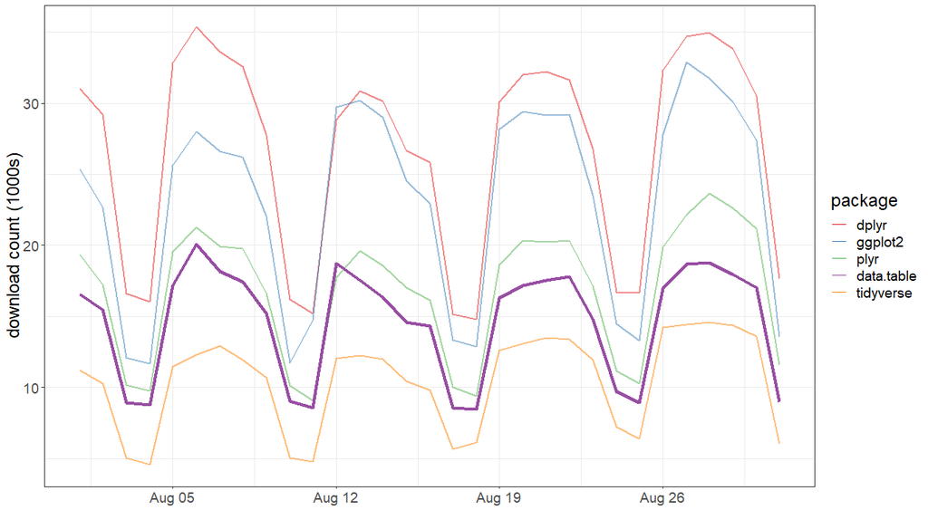

>   data pulled using `cranlogs` package
- `data.table` is fast (especially on larger data)

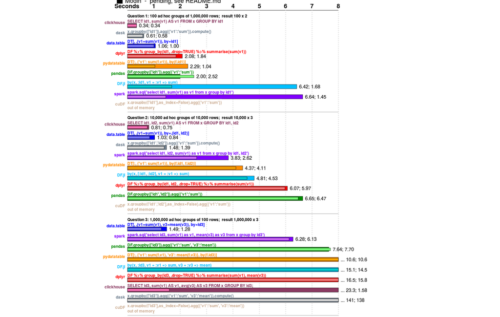

  https://h2oai.github.io/db-benchmark/

## Why do we care?

> - `data.table` comes with other features (file i/o, reshape functions)
> - no need for multiple package dependencies
> - syntax is clean, compact, and consistent
> - `data.tables` are compatible with any function that takes `data.frame`s

# `data.table` basics

## Load data

```r
# import data.table library
library(data.table)

data_file <- here::here("data", "ca_energy_generation.csv")

# read in two versions of data, one as a data.frame and one as a data.table
generation_df <- read.csv(data_file, stringsAsFactors = F)

generation_dt <- fread(data_file)
```

## `data.table` inherits from a `data.frame`.

```r
class(generation_df)
```

```
## [1] "data.frame"
```

```r
class(generation_dt)
```

```
## [1] "data.table" "data.frame"
```

```r
View(generation_df)
View(generation_dt)
generation_df
generation_dt
str(generation_df)
str(generation_dt)
```

# How to use `data.table`s

## `data.table` syntax

> - `dplyr` syntax: depends on a small set of verbs
> - `data.table` syntax: small set of consistent rules input into `dt[]`
> - column names are variables inside `dt[]`

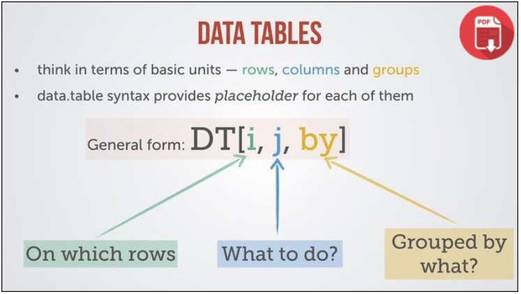

> - https://github.com/Rdatatable/data.table/wiki

# `i`: “on which rows” (row filtering)

- logical operations filter rows

```r
generation_dt[wind > 4400]
```

```
##                datetime   biogas  biomass      coal geothermal large_hydro
##  1: 2019-09-07 17:00:00 237.5000 395.1667  5.083333   956.1667    2626.250
##  2: 2019-09-07 21:00:00 236.8333 390.3333  6.000000   964.5000    3395.917
##  3: 2019-09-07 22:00:00 236.9167 390.8333  6.000000   968.1667    3101.333
##  4: 2019-09-08 18:00:00 235.0833 369.0833 14.166667   960.5000    3981.000
##  5: 2019-09-08 19:00:00 233.5833 368.6667 14.000000   963.6667    4308.500
##  6: 2019-09-09 17:00:00 233.9167 389.4167 13.750000   974.6667    3075.417
##  7: 2019-09-09 18:00:00 230.1667 390.0833 12.833333   975.9167    4215.917
##  8: 2019-09-09 19:00:00 228.0000 388.4167 12.000000   978.5000    4413.583
##  9: 2019-09-09 20:00:00 227.8333 386.4167 12.583333   979.7500    4414.667
## 10: 2019-09-09 21:00:00 231.1667 383.1667 12.333333   980.5833    3771.417
## 11: 2019-09-09 22:00:00 231.1667 368.9167 13.083333   980.5833    3305.167
## 12: 2019-09-09 23:00:00 231.5000 358.9167 13.750000   980.3333    2704.583
##     natural_gas  nuclear other small_hydro      solar     wind
##  1:   10375.833 2257.250     0    394.5833 6680.25000 4434.000
##  2:    9712.000 2250.167     0    409.1667    0.00000 4409.583
##  3:    8878.417 2249.083     0    406.9167    0.00000 4408.667
##  4:    7189.500 2261.750     0    445.2500 1975.66667 4427.250
##  5:    7809.333 2263.417     0    470.1667   31.58333 4578.083
##  6:    8239.750 2267.083     0    446.4167 6408.91667 4426.667
##  7:    9688.667 2268.167     0    458.1667 1722.00000 4616.583
##  8:    9761.583 2269.000     0    480.6667   19.75000 4894.417
##  9:    9210.583 2267.583     0    467.1667    0.00000 4824.750
## 10:    8475.083 2265.417     0    471.7500    0.00000 4677.917
## 11:    8056.750 2265.417     0    435.6667    0.00000 4681.917
## 12:    6895.417 2266.000     0    413.1667    0.00000 4571.417
```

- logical operations filter rows

```r
generation_dt[wind > 4400 & mday(datetime) == 7]
```

```
##               datetime   biogas  biomass     coal geothermal large_hydro
## 1: 2019-09-07 17:00:00 237.5000 395.1667 5.083333   956.1667    2626.250
## 2: 2019-09-07 21:00:00 236.8333 390.3333 6.000000   964.5000    3395.917
## 3: 2019-09-07 22:00:00 236.9167 390.8333 6.000000   968.1667    3101.333
##    natural_gas  nuclear other small_hydro   solar     wind
## 1:   10375.833 2257.250     0    394.5833 6680.25 4434.000
## 2:    9712.000 2250.167     0    409.1667    0.00 4409.583
## 3:    8878.417 2249.083     0    406.9167    0.00 4408.667
```

**Exercise:**

- **try it!** select rows for which natural gas generation is less than or equal to 5,000 MW and large hydro generation is greater than 2,000 MW
- **bonus:** select rows for which coal generation is greater than 10 MW and solar generation is greater than the median value of solar generation

**Answers:**

```r
generation_dt[natural_gas <= 5000 & large_hydro > 2000]
```

```
##               datetime   biogas  biomass     coal geothermal large_hydro
## 1: 2019-09-08 02:00:00 237.1667 374.3333 4.083333   969.9167    2217.667
## 2: 2019-09-08 03:00:00 237.8333 342.5000 4.000000   972.5000    2090.917
##    natural_gas  nuclear other small_hydro solar     wind
## 1:     4530.75 2255.583     0    385.0833     0 2928.083
## 2:     4079.50 2257.500     0    377.5000     0 2726.583
```

```r
generation_dt[coal > 10 & solar > median(solar)]
```

```
##                datetime   biogas  biomass     coal geothermal large_hydro
##  1: 2019-09-08 18:00:00 235.0833 369.0833 14.16667   960.5000    3981.000
##  2: 2019-09-09 07:00:00 218.5833 375.8333 13.00000   978.5833    2704.333
##  3: 2019-09-09 08:00:00 215.1667 374.5000 13.08333   975.8333    1841.333
##  4: 2019-09-09 09:00:00 214.5000 378.3333 13.00000   970.8333    1289.500
##  5: 2019-09-09 10:00:00 217.7500 381.5000 13.25000   967.3333    1631.250
##  6: 2019-09-09 11:00:00 217.4167 376.9167 12.66667   965.2500    1633.583
##  7: 2019-09-09 12:00:00 224.8333 379.5000 10.83333   965.0833    1679.000
##  8: 2019-09-09 13:00:00 231.0833 383.1667 11.50000   964.2500    1790.500
##  9: 2019-09-09 14:00:00 230.9167 383.5000 12.16667   968.8333    1851.667
## 10: 2019-09-09 15:00:00 231.3333 383.4167 11.91667   969.0000    2081.833
## 11: 2019-09-09 16:00:00 233.8333 389.0000 13.16667   970.7500    2340.917
## 12: 2019-09-09 17:00:00 233.9167 389.4167 13.75000   974.6667    3075.417
## 13: 2019-09-09 18:00:00 230.1667 390.0833 12.83333   975.9167    4215.917
##     natural_gas  nuclear other small_hydro     solar     wind
##  1:    7189.500 2261.750     0    445.2500  1975.667 4427.250
##  2:    6226.417 2265.583     0    389.8333  2518.333 2910.750
##  3:    5214.250 2266.333     0    360.7500  7190.083 2882.083
##  4:    4615.167 2265.417     0    380.2500  9542.917 2948.000
##  5:    4147.250 2263.583     0    405.0833 10451.333 2666.417
##  6:    4174.167 2264.417     0    406.6667 10780.500 2308.833
##  7:    4239.667 2264.667     0    408.3333 10760.917 1942.750
##  8:    4693.667 2265.583     0    409.0833 10629.333 2760.000
##  9:    4919.750 2265.417     0    406.0833 10655.167 3554.750
## 10:    5748.917 2266.583     0    438.5833 10067.250 3882.667
## 11:    7001.917 2266.583     0    446.3333  9051.583 4076.917
## 12:    8239.750 2267.083     0    446.4167  6408.917 4426.667
## 13:    9688.667 2268.167     0    458.1667  1722.000 4616.583
```

# `j`: “what to do” (column operations)

- perform any operation in `j`

```r
generation_dt[,wind + solar]
```

```
##   [1]  2670.1667  2778.8333  2795.2500  2582.5833  2397.4167  2327.0000
##   [7]  2126.0000  4249.8333  8343.7500 10104.5833 10781.7500 11175.4167
##  [13] 10895.1667 10635.0000 10480.1667 10241.2500  9942.6667  8699.4167
##  [19]  5307.5000  3776.0000  3408.4167  3097.4167  3059.3333  2893.5000
##  [25]  2523.5833  2415.9167  2206.0833  1649.6667   991.5000   714.9167
##  [31]   578.5833  2986.0833  7418.0000  9533.1667 10372.3333 10615.9167
##  [37] 10469.1667 10261.6667 10352.5833  9811.7500  8002.6667  5165.4167
##  [43]  2507.4167  1695.5000  1832.7500  2062.9167  1996.0833  1735.4167
##  [49]  1622.5000  1723.5000  1849.0833  1552.1667  1425.1667  1363.3333
##  [55]  1326.6667  2620.3333  5961.3333  8104.1667  8849.3333  9843.5833
##  [61]  9907.4167  9185.5833  9527.7500  9888.7500  9072.5833  6852.8333
##  [67]  3443.2500  2118.6667  2189.3333  2078.9167  2027.2500  1928.6667
##  [73]  2227.0833  2092.5833  1837.6667  1886.5833  1822.4167  1663.6667
##  [79]  1527.5833  3717.2500  8016.8333 10204.8333 10926.2500 11134.8333
##  [85] 11271.8333 11483.9167 11843.9167 12003.3333 11428.9167  8994.5000
##  [91]  5060.3333  3684.5000  4054.5833  4049.4167  4154.1667  4107.7500
##  [97]  4078.8333  3859.2500  3878.7500  3809.9167  3812.6667  3672.5000
## [103]  3711.5833  6138.2500 10841.7500 12954.9167 13769.2500 14285.5833
## [109] 14550.0833 14712.9167 14774.4167 14117.0000 13483.0833 11114.2500
## [115]  6067.6667  3600.3333  4045.8333  4409.5833  4408.6667  4294.0833
## [121]  3628.0833  3118.0833  2928.0833  2726.5833  2677.9167  2772.1667
## [127]  2887.3333  6014.0833 10932.0000 13178.7500 14233.3333 14432.0000
## [133] 14629.0000 14842.8333 14834.3333 14302.6667 13498.8333 11223.0833
## [139]  6402.9167  4609.6667  4364.6667  4007.0833  4198.9167  4175.6667
## [145]  4023.4167  4062.1667  4153.3333  3959.5833  3683.6667  3523.8333
## [151]  3275.3333  5429.0833 10072.1667 12490.9167 13117.7500 13089.3333
## [157] 12703.6667 13389.3333 14209.9167 13949.9167 13128.5000 10835.5833
## [163]  6338.5833  4914.1667  4824.7500  4677.9167  4681.9167  4571.4167
```

- perform any operation in `j`

```r
generation_dt[,3*wind + solar*biogas/2]
```

```
##   [1]    8010.500    8336.500    8385.750    7747.750    7192.250    6981.000
##   [7]   15281.104  299488.556  834963.403 1067313.865 1152190.219 1224516.809
##  [13] 1208937.063 1167009.750 1144680.503 1057525.139  940937.062  720226.851
##  [19]  253363.437   36299.972   20083.757    9292.250    9178.000    8680.500
##  [25]    7570.750    7247.750    6618.250    4949.000    2974.500    2144.750
##  [31]   11623.257  301048.875  818965.771 1070041.833 1162682.375 1186467.375
##  [37] 1158653.917 1130800.819 1101875.361 1012419.097  774473.892  459216.771
##  [43]  130539.844    8291.333    5498.250    6188.750    5988.250    5206.250
##  [49]    4867.500    5170.500    5547.250    4656.500    4275.500    4090.000
##  [55]    7679.552  174050.236  542303.764  778465.625  896767.083 1025437.618
##  [61] 1039308.708  962964.028 1006242.375 1047985.944  923123.903  622641.361
##  [67]  205340.479    9971.083    6568.000    6236.750    6081.750    5786.000
##  [73]    6681.250    6277.750    5513.000    5659.750    5467.250    4991.000
##  [79]   12171.083  288830.812  821286.694 1074298.962 1169842.569 1208043.875
##  [85] 1196018.538 1192192.736 1167777.531 1148957.292 1033514.406  730203.069
##  [91]  240335.312   15614.528   12163.750   12148.250   12462.500   12323.250
##  [97]   12236.500   11577.750   11636.250   11429.750   11438.000   11017.500
## [103]   19031.681  329184.885  898422.906 1160500.597 1243934.573 1269358.573
## [109] 1263524.375 1258327.448 1259339.399 1225493.201 1124938.833  806581.688
## [115]  243456.469   14963.181   12137.500   13228.750   13226.000   12882.250
## [121]   10884.250    9354.250    8784.250    8179.750    8033.750    8316.500
## [127]   19276.000  342521.979  870872.969 1129279.528 1252038.667 1270701.833
## [133] 1281800.875 1295271.087 1289723.847 1240913.569 1120508.222  821549.778
## [139]  245504.903   17422.920   13094.000   12021.250   12596.750   12527.000
## [145]   12070.250   12186.500   12460.000   11878.750   11051.000   10571.500
## [151]   16690.240  283965.097  782179.382 1032321.813 1145888.167 1178856.688
## [157] 1215534.632 1236410.889 1240892.035 1176093.250 1070511.701  762856.212
## [163]  212023.250   16934.750   14474.250   14033.750   14045.750   13714.250
```

- new columns may be assigned in `j` or a new table can be created

```r
generation_dt[,newcol := 3*wind + solar*biogas/2]

generation_dt[,.(newcol = 3*wind + solar*biogas/2)]
```

```
##        newcol
##   1:  8010.50
##   2:  8336.50
##   3:  8385.75
##   4:  7747.75
##   5:  7192.25
##  ---
## 164: 16934.75
## 165: 14474.25
## 166: 14033.75
## 167: 14045.75
## 168: 13714.25
```

- columns may be deleted in `j`

```r
generation_dt[,newcol := NULL]
```

**Exercise:**

- **try it!** add a column called “total_hydro” that is the sum of the `small_hydro` and `large_hydro` columns
- **try it!** find the mean of the `nuclear` and `biogas` columns
- **bonus:** create a new table: for the hours when solar generation is zero, get the `datetime` and `total_thermal` (sum of natural gas and coal generation)

**Answers**

```r
generation_dt[,total_hydro := small_hydro + large_hydro]

# generation_dt[,mean(nuclear)]
# generation_dt[,mean(biogas)]
# or
generation_dt[,.(mean(nuclear), mean(biogas))]
```

```
##          V1       V2
## 1: 2253.677 234.6855
```

```r
# or, with column names
# generation_dt[,.(mean_nuc = mean(nuclear), mean_biogas = mean(biogas))]

generation_dt[solar == 0, .(datetime, total_thermal = natural_gas + coal)]
```

```
##                datetime total_thermal
##  1: 2019-09-03 00:00:00      9719.833
##  2: 2019-09-03 01:00:00      9164.000
##  3: 2019-09-03 02:00:00      8087.333
##  4: 2019-09-03 03:00:00      7811.083
##  5: 2019-09-03 04:00:00      7753.750
##  6: 2019-09-03 05:00:00      8634.583
##  7: 2019-09-03 21:00:00     16464.917
##  8: 2019-09-03 22:00:00     14814.333
##  9: 2019-09-03 23:00:00     12597.417
## 10: 2019-09-04 00:00:00     10715.333
## 11: 2019-09-04 01:00:00      9714.750
## 12: 2019-09-04 02:00:00      9464.667
## 13: 2019-09-04 03:00:00      9293.583
## 14: 2019-09-04 04:00:00      9670.417
```

[output cut: 56 more lines]

# `by`: “grouped by what”

- add grouping to any operation

```r
generation_dt[,mean(nuclear), by = mday(datetime)]
```

```
##    mday       V1
## 1:    3 2246.920
## 2:    4 2246.087
## 3:    5 2253.396
## 4:    6 2252.580
## 5:    7 2254.882
## 6:    8 2257.490
## 7:    9 2264.385
```

- combine with everything we’ve learned about `i` and `j`

```r
generation_dt[,.(mean_nuc = mean(nuclear), mean_wind = mean(wind)),
              by = mday(datetime)]
```

```
##    mday mean_nuc mean_wind
## 1:    3 2246.920  2095.382
## 2:    4 2246.087  1190.125
## 3:    5 2253.396  1504.118
## 4:    6 2252.580  2225.656
## 5:    7 2254.882  3907.955
## 6:    8 2257.490  3696.674
## 7:    9 2264.385  3718.628
```

- combine with everything we’ve learned about `i` and `j`

```r
generation_dt[hour(datetime) > 19,
              .(mean_nuc = mean(nuclear), mean_wind = mean(wind)),
              by = mday(datetime)]
```

```
##    mday mean_nuc mean_wind
## 1:    3 2247.146  3093.312
## 2:    4 2249.604  1906.792
## 3:    5 2257.021  2056.042
## 4:    6 2255.146  4091.479
## 5:    7 2250.583  4289.542
## 6:    8 2259.500  4186.583
## 7:    9 2266.104  4689.000
```

**Exercise:**

- **try it!** find the median solar generation by hour.
- **try it!** for hours when the solar generation is greater than zero, find the maximum natural gas generation by day

**Answers:**

```r
generation_dt[,median(solar), by = hour(datetime)]
```

```
##     hour          V1
##  1:    0     0.00000
##  2:    1     0.00000
##  3:    2     0.00000
##  4:    3     0.00000
##  5:    4     0.00000
##  6:    5     0.00000
##  7:    6    67.83333
##  8:    7  2518.33333
##  9:    8  7055.75000
## 10:    9  9271.00000
## 11:   10 10088.25000
## 12:   11 10474.08333
## 13:   12 10284.16667
## 14:   13 10063.66667
## 15:   14  9899.41667
## 16:   15  9688.33333
## 17:   16  8736.41667
## 18:   17  6269.41667
## 19:   18  1939.75000
## 20:   19    31.58333
## 21:   20     0.00000
## 22:   21     0.00000
## 23:   22     0.00000
## 24:   23     0.00000
##     hour          V1
```

```r
generation_dt[solar > 0, max(natural_gas), by = mday(datetime)]
```

```
##    mday        V1
## 1:    3 20725.667
## 2:    4 23359.583
## 3:    5 22071.667
## 4:    6 18611.000
## 5:    7 11380.083
## 6:    8  7809.333
## 7:    9  9761.583
```

## `data.table` syntax recap

> - column names are variables inside `dt[]`

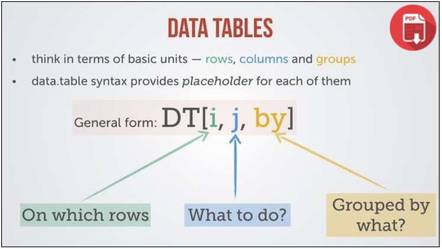

> - the combination of `i`, `j`, and `by` is very powerful
> - few other components; outside scope of this review

# `data.table` upgrades to other functions

`data.table` co-opts some functions we’ve already talked about

> - `melt`
> - `dcast`
> - `merge`
> - `order`
> - This means we can repeat what we did with dplyr almost exactly

## `dplyr` -> `data.table`

**Exercise:**

**try it!** Convert this `dplyr` syntax into `data.table` syntax (remember that this created the columns `day`, `log_output`, and `per_output`)

```r
long_ca_energy <- long_ca_energy %>%
  mutate(day = as_date(datetime),
         log_output = log(output)) %>%
  group_by(day) %>%
  mutate(total_daily_output = sum(output, na.rm = T)) %>%
  ungroup() %>%
  mutate(per_output = output/total_daily_output)
```

**Answers**

```r
long_ca_energy <- long_ca_energy %>%
  mutate(day = as_date(datetime),
         log_output = log(output)) %>%
  group_by(day) %>%
  mutate(total_daily_output = sum(output, na.rm = T)) %>%
  ungroup() %>%
  mutate(per_output = output/total_daily_output)

# becomes
all_generation_long[,day := as_date(datetime)]
all_generation_long[,log_output := log(value)]
all_generation_long[,per_output := value/sum(value), by = day]
```

## `dplyr` -> `data.table`

```r
long_ca_energy <- long_ca_energy %>%
  mutate(day = as_date(datetime),
         log_output = log(output)) %>%
  group_by(day) %>%
  mutate(total_daily_output = sum(output, na.rm = T)) %>%
  ungroup() %>%
  mutate(per_output = output/total_daily_output)

# becomes
all_generation_long[,day := as_date(datetime)]
all_generation_long[,log_output := log(value)]
all_generation_long[,per_output := value/sum(value), by = day]
```

It is also possible to do this in one command:

```r
all_generation_long[,`:=`(day2 = as_date(datetime),
                          log_output2 = log(value),
                          per_output2 = value/sum(value)),
                    by = day]
```

# `fread` and `fwrite`

> - “Fast and friendly file finagler” - *help file*
> - “Similar to read.table but faster and more convenient” - *help file*
> - `stringsAsFactors=FALSE` already set

## fread benchmarks

```r
# example, no need to run this
library(rbenchmark)

# this will run each command 100 times and report the average time taken

# 168 lines
data_file <- "generation.csv"
benchmark(read.csv(data_file, stringsAsFactors = F),
          fread(data_file),
          replications = 500)

#                                        test replications elapsed relative user.self sys.self user.child sys.child
# 2                          fread(data_file)          500    0.62    1.000      0.50     0.12         NA        NA
# 1 read.csv(data_file, stringsAsFactors = F)          500    0.67    1.081      0.54     0.13         NA        NA

# 12,600 lines
data_file_medium <- "generation_medium.csv"
benchmark(read.csv(data_file_medium, stringsAsFactors = F),
          fread(data_file_medium))

#                                               test replications elapsed relative user.self sys.self user.child sys.child
# 2                          fread(data_file_medium)          100    0.77    1.000      0.72     0.05         NA        NA
# 1 read.csv(data_file_medium, stringsAsFactors = F)          100    4.28    5.558      4.22     0.06         NA        NA

# 1,008,000 lines
data_file_large <- "generation_large.csv"
benchmark(read.csv(data_file_large, stringsAsFactors = F),
          fread(data_file_large),
          replications = 20)

#                                              test replications elapsed relative user.self sys.self user.child sys.child
# 2                          fread(data_file_large)           20    2.67    1.000      7.07     1.10         NA        NA
# 1 read.csv(data_file_large, stringsAsFactors = F)           20   74.59   27.936     71.53     3.05         NA        NA
```

# `set` functions

- `set` functions update properties of the `data.table` by reference

```r
# set column names
setnames(dt, "old", "new")

# set row order
setorder(dt, col1, -col2, ...)

# set anything
set(dt, i, j)

# set colum
dt[,col1 := 2*col2]
```

# Special variables

`data.table`s also contain some special read-only symbols that are often useful:

- `.N`: number of rows in the current group
- `.I`: a vector, `1:nrow(dt)`, usually used for more advanced operations

```r
# for .N: convenient
all_generation_long[,.N]
all_generation_long[,.N, by = type]

# for .I: more advanced syntax
all_generation_long[,.I]
```

# Other features: keys

- keys: one or more columns, pre-sorted index of the table.

```r
# check the current key
key(generation_dt)

# set key
setkey(generation_dt, datetime)
key(generation_dt)
```

# Other features: joins

- joins: `data.table` has a special join syntax

```r
imports_dt <- fread(here::here("data", "ca_energy_imports.csv"))

imports_dt
```

```
##                 datetime   imports
##   1: 2019-09-03 00:00:00  7527.333
##   2: 2019-09-03 01:00:00  6930.333
##   3: 2019-09-03 02:00:00  7005.833
##   4: 2019-09-03 03:00:00  7080.583
##   5: 2019-09-03 04:00:00  7421.667
##  ---
## 164: 2019-09-09 19:00:00 10002.667
## 165: 2019-09-09 20:00:00  9994.083
## 166: 2019-09-09 21:00:00  9690.167
## 167: 2019-09-09 22:00:00  7998.000
## 168: 2019-09-09 23:00:00  7570.750
```

- joins: `data.table` has a special join syntax

```r
# set key or specify on
imports_dt[generation_dt, on = "datetime"]
```

```
##                 datetime   imports   biogas  biomass      coal geothermal
##   1: 2019-09-03 00:00:00  7527.333 238.9167 407.0833  9.000000   967.2500
##   2: 2019-09-03 01:00:00  6930.333 239.0000 406.5000  9.000000   970.3333
##   3: 2019-09-03 02:00:00  7005.833 239.0000 406.8333  9.000000   973.1667
##   4: 2019-09-03 03:00:00  7080.583 238.9167 407.1667  9.833333   973.8333
##   5: 2019-09-03 04:00:00  7421.667 237.9167 406.0833  9.416667   974.6667
##  ---
## 164: 2019-09-09 19:00:00 10002.667 228.0000 388.4167 12.000000   978.5000
## 165: 2019-09-09 20:00:00  9994.083 227.8333 386.4167 12.583333   979.7500
## 166: 2019-09-09 21:00:00  9690.167 231.1667 383.1667 12.333333   980.5833
## 167: 2019-09-09 22:00:00  7998.000 231.1667 368.9167 13.083333   980.5833
## 168: 2019-09-09 23:00:00  7570.750 231.5000 358.9167 13.750000   980.3333
##      large_hydro natural_gas  nuclear other small_hydro solar     wind
##   1:    3152.500    9710.833 2248.750     0    401.6667  0.00 2670.167
##   2:    2724.333    9155.000 2250.583     0    400.9167  0.00 2778.833
```

[output cut: 21 more lines]

- joins: `data.table` has a special join syntax

```r
# operations can be performed in the same step as the merge
imports_dt[generation_dt, on = "datetime", imports_gas := imports + i.natural_gas]

imports_dt
```

```
##                 datetime   imports imports_gas
##   1: 2019-09-03 00:00:00  7527.333    17238.17
##   2: 2019-09-03 01:00:00  6930.333    16085.33
##   3: 2019-09-03 02:00:00  7005.833    15084.17
##   4: 2019-09-03 03:00:00  7080.583    14881.83
##   5: 2019-09-03 04:00:00  7421.667    15166.00
##  ---
## 164: 2019-09-09 19:00:00 10002.667    19764.25
## 165: 2019-09-09 20:00:00  9994.083    19204.67
## 166: 2019-09-09 21:00:00  9690.167    18165.25
## 167: 2019-09-09 22:00:00  7998.000    16054.75
## 168: 2019-09-09 23:00:00  7570.750    14466.17
```

- joins: `data.table` has a special join syntax

```r
# operations can be performed in the same step as the merge
imports_dt[generation_dt[hour(datetime) == 2], on = "datetime", imports_gas_2 := imports + i.natural_gas]

imports_dt
```

```
##                 datetime   imports imports_gas imports_gas_2
##   1: 2019-09-03 00:00:00  7527.333    17238.17            NA
##   2: 2019-09-03 01:00:00  6930.333    16085.33            NA
##   3: 2019-09-03 02:00:00  7005.833    15084.17      15084.17
##   4: 2019-09-03 03:00:00  7080.583    14881.83            NA
##   5: 2019-09-03 04:00:00  7421.667    15166.00            NA
##  ---
## 164: 2019-09-09 19:00:00 10002.667    19764.25            NA
## 165: 2019-09-09 20:00:00  9994.083    19204.67            NA
## 166: 2019-09-09 21:00:00  9690.167    18165.25            NA
## 167: 2019-09-09 22:00:00  7998.000    16054.75            NA
## 168: 2019-09-09 23:00:00  7570.750    14466.17            NA
```

# Library Management

- dplyr, data.table, and reshape2 not only share similar functions, but sometimes share function names
- in these cases, the package loaded most recently will be the function used
- this is important for many reasons, but especially when working between data.frame and data.table
- let’s look at the function ‘melt’

# Library Management

- let’s look at the function ‘melt’
- we know that melt is a data.table function
- we’ve been working a lot with data.tables
- what package do we expect melt to be loading from?

# Library Management

- what package do we expect melt to be loading from?

```r
melt
```

```
## function (data, ..., na.rm = FALSE, value.name = "value")
## {
##     UseMethod("melt", data)
## }
## <bytecode: 0x7f9f268a1b90>
## <environment: namespace:reshape2>
```

# Library Management

- and if we use this function, what object do we receive?

```r
cat('is.data.table: ', is.data.table(melt(imports_dt, 0)),
    '\nis.data.frame: ', is.data.frame(melt(imports_dt, 0)))
```

```
## is.data.table:  FALSE
## is.data.frame:  TRUE
```

# Library Management

- how to specify functions
- explicit function name
- the function is still there, but given a verbose reference

```r
is.data.table(
  melt.data.table(imports_dt,
                          id.vars = "datetime",
                          variable.name = "source",
                          value.name = "output"))
```

```
## [1] TRUE
```

# Library Management

- how to specify functions
- reference intended library

```r
is.data.table(
  data.table::melt(imports_dt,
                          id.vars = "datetime",
                          variable.name = "source",
                          value.name = "output"))
```

```
## [1] TRUE
```

## Library Management

- how to specify functions
- set function reference

```r
melt <- data.table::melt

is.data.table(
              melt(imports_dt,
                          id.vars = "datetime",
                          variable.name = "source",
                          value.name = "output"))
```

```
## [1] TRUE
```

# Library Management

- how to specify functions
- reload libraries in desired order

```r
#knit is crashing here, but the output is in slides
#unloadNamespace("reshape2")
#unloadNamespace("data.table")
#library(reshape2)
#library(data.table)
```

```r
is.data.table(
  melt(imports_dt,
                          id.vars = "datetime",
                          variable.name = "source",
                          value.name = "output"))
```

```
## [1] TRUE
```

# Library Management

-lastly, a function to review all overwritten functions

```r
conflicted <- base::conflicts()

which_packages_by_function <- lapply(conflicted, utils::find)

names(which_packages_by_function) <- conflicted

which_packages_by_function[0:5]
```

```
## $melt
## [1] ".GlobalEnv"         "package:reshape2"   "package:data.table"
##
## $dcast
## [1] "package:reshape2"   "package:data.table"
##
## $melt
## [1] ".GlobalEnv"         "package:reshape2"   "package:data.table"
##
## $`body<-`
## [1] "package:methods" "package:base"
##
## $kronecker
## [1] "package:methods" "package:base"
```

# Final thoughts

- developers: Matt Dowle, Arun Srinivasan (look out for them on stack overflow)
- useful [introduction](https://cran.r-project.org/web/packages/data.table/vignettes/datatable-intro.html) to `data.table`
- also useful `data.table` [FAQ](https://cran.r-project.org/web/packages/data.table/vignettes/datatable-faq.html)
- [Intro to advanced features](https://cran.r-project.org/web/packages/data.table/vignettes/datatable-reshape.html) of `data.table` `melt` and `dcast` functions
- or any other vignette